# Resouce use in two sympatric species of sea snakes in anthropogenically dominated seascape

Analysis for manuscript

# 1 Introduction

The core message of this manuscripts are as follows:

- Resource use differs between *H. curtus* and *H. schistosus*
- Variation in fishing intensity of trawlers and gillnets affects patterns of resource use

This file was last update on 2020-05-19

# 2 Varition in fishing intensity along the sindhudurg coast

How do we use location and depth data gathered from fisher surveys to map fishing intensity?

- Nearest landmarks are geocoded from google maps API
- Latitude is extracted from landmark geocode
- Match landmark latitude and depth from survey to GEBCO data
- Extract final longitude from GEBCO data

## 2.1 Calculating effort with depth

**Fishing intensity**: Vessel effort = Number of days fishing x No. of hauls x Average time per haul is calculated for each boat on each day. This is then totaled for the sampling duration at each site.

- Should fishing intensity be analysed seperately by fishing gear.
- Should calculation of fishing intensity factor in Gears.

```r
dep_int = effort%>%
  filter(Fishing.Location != "")%>% #removing missing location data
  dplyr::select(Date, Gear.Type, Fishing.Location, Boat.name,
                No..of.Hauls, Average.Haul.Time..Hours., No..of.Days.fishing, Depth..wav.)%>%
  group_by(Gear.Type)%>%
  mutate(n.days = ifelse(is.na(No..of.Days.fishing), #filling in missing data with means
                         median(No..of.Days.fishing, na.rm = T), No..of.Days.fishing),
         n.hauls = ifelse(is.na(No..of.Hauls),
                          mean(No..of.Hauls, na.rm = T), No..of.Hauls),
         haul.time = ifelse(is.na(Average.Haul.Time..Hours.),
                            mean(Average.Haul.Time..Hours., na.rm = T), Average.Haul.Time..Hours.))%>%
  ungroup()%>%
  mutate(effort =
           (n.days)*(n.hauls)*(haul.time),
         Depth.m = Depth..wav.*1.87)%>%
  dplyr::select(Date, Boat.name, Gear.Type, Fishing.Location, Depth.m, effort)%>%
  drop_na()
```

| Var1 | Freq |
| --- | --- |
| GillNet | 163 |
| Trawler | 107 |

**Variable type: numeric**

| skim_variable | Gear.Type | n_missing | complete_rate | mean | sd | p0 | p25 | p50 | p75 | p100 | hist |
| --- | --- | --- | --- | --- | --- | --- | --- | --- | --- | --- | --- |
| effort | GillNet | 0 | 1 | 1.12 | 0.67 | 0.17 | 0.75 | 1.00 | 1 | 4 | ▅▇▂▁▁ |
| effort | Trawler | 0 | 1 | 17.33 | 7.92 | 4.00 | 12.00 | 17.38 | 18 | 48 | ▅▇▂▁▁ |

| estimate | estimate1 | estimate2 | statistic | p.value |
| --- | --- | --- | --- | --- |
| -16.20868 | 1.120948 | 17.32963 | -21.11231 | 0 |

```
## [1] 3.235314
```

## 2.2 Mapping fishing intensity

```r
# Geocoding local intensity data with depth
dep_int = dep_int%>%
  ungroup()%>%
  mutate(Fishing.Location = as.character(Fishing.Location))%>%
  mutate_geocode(location = Fishing.Location)

# Extracting coordinates from depth data

library(fuzzyjoin)

#matching funtions for theta join

depth_match <- function(x,y){
  x <- -x
  x <= y+0.5 & x >= y-0.5 #interval for theta matching depth
}

lat_match <- function(x,y){
  x <= y+0.005 & x >= y-0.005 #interval for theta matching latitude
}

dep_int <- dep_int%>%
  mutate(depth = Depth.m)%>%
  fuzzy_inner_join(y = depth, by = c("depth", "lat"),
                   match_fun = list(depth = depth_match,
                                    lat = lat_match))%>%
  dplyr::select(Date, Boat.name, Fishing.Location, Gear.Type, Depth.m,
                effort, lon.y, lat.x)%>%#dplyr::selecting relevant variables
  rename(lon = lon.y,# longitude from fishing location
         lat = lat.x)# latitude from depth data

dep_int <- distinct(dep_int, Date, Boat.name, .keep_all = T)

#Saving geocoded depth data to save computation time

write.csv(dep_int, "./Data/Fishing intensity_dep.csv")
```

[output not shown]

[output not shown]

[output not shown]

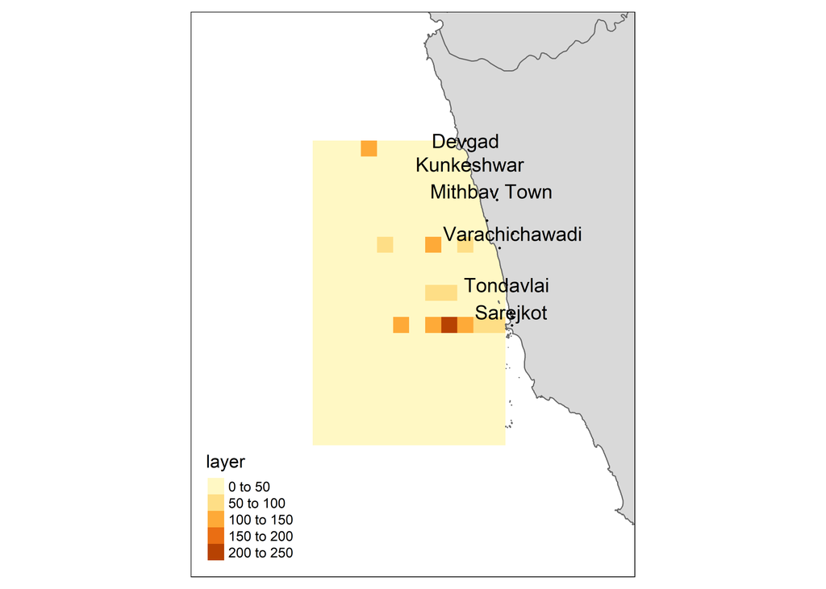

[figure not shown]

*Are points accurately depicted?*

Survey based map of fishing intensity needs to be verified with onboard observations and/or remote GPS data.

| Gear.Type | ext |
| --- | --- |
| GillNet | 47 |
| Trawler | 94 |

# 3 DIfference in distribution and habitat use between *H. curtus* and *H. shcistosus*

## 3.1 Mapping sea snake distribution with fisheries survey data

```r
#Calculating sea snake abundance

snakes_den = snakes%>%
  filter(Species == "Hydrophis schistosus" | Species == "Hydrophis curtus",
         Fishing.Location != "",
         !is.na(Depth.Caught..m.))%>%
  dplyr::select(Species, Fishing.Location, Depth.Caught..m., Date, Boat.Name.Owner,
         No..of.Hauls, Average.Haul.Duration..Hours., Gear.Type)%>%
  group_by(Gear.Type)%>%
  mutate(n.hauls = ifelse(is.na(No..of.Hauls),
                         median(No..of.Hauls, na.rm = T), No..of.Hauls),
         haul.time = ifelse(is.na(Average.Haul.Duration..Hours.),
                         median(Average.Haul.Duration..Hours., na.rm = T),
                         Average.Haul.Duration..Hours.))%>%
  group_by(Date, Boat.Name.Owner)%>%
  summarise(HC = sum(Species == "Hydrophis curtus"),
         HS = sum(Species == "Hydrophis schistosus"),
         effort = last(n.hauls*haul.time),
         Fishing.Location = last(Fishing.Location),
         Depth.Caught..m. = last(Depth.Caught..m.))%>%
  gather(c("HC", "HS"), value = n, key = "Species")%>%
  mutate(CPUE = n/effort)%>%
  drop_na()

#Geocoding sea snake density

snakes_den = snakes_den%>%
  ungroup()%>%
  mutate(Fishing.Location = as.character(Fishing.Location))%>%
  mutate_geocode(location = Fishing.Location)

#Extracting point data from depth and location

library(fuzzyjoin)

#matching funtions for theta join

depth_match <- function(x,y){
  x <- -x
  x <= y+0.5 & x >= y-0.5 #interval for theta matching depth
}

lat_match <- function(x,y){
  x <= y+0.005 & x >= y-0.005 #interval for theta matching latitude
}

snakes_den <- snakes_den%>%
  mutate(depth = Depth.Caught..m.)%>%
  fuzzy_inner_join(y = depth, by = c("depth", "lat"),
                   match_fun = list(depth = depth_match,
                                    lat = lat_match))%>%
  dplyr::select(Date, Boat.Name.Owner, Species, Fishing.Location, Depth.Caught..m.,
         lon.y, lat.x, CPUE, n)%>%#dplyr::selecting relevant variables
  rename(lon = lon.y,# longitude from fishing location
         lat = lat.x)%>%# latitude from depth data
  distinct(Date, Boat.Name.Owner, Species, Fishing.Location, Depth.Caught..m., .keep_all = T)

write.csv(snakes_den, "./Data/snakes-density.csv")#saved data set to reduce compute time
```

| Gear.Type | n | effort |
| --- | --- | --- |
| GillNet | 396 | 541.12 |
| Rampan | 60 | 214.90 |
| Trawler | 40 | 185.50 |

[output not shown]

| Species | ext |
| --- | --- |
| Hydrophis curtus | 49 |
| Hydrophis schistosus | 51 |

[output not shown]

[output not shown]

Do *H. schistosus* and *H.curtus* partition the coastal habitat along the depth axis?

## 3.2 Summarising depth use by species

[output not shown]

[output not shown]

## 3.3 Spatial segregation by species

[output not shown]

## 3.4 Modelling depth use by species

[output not shown]

[output not shown]

# 4 DIfference in diet between *H. curtus* and *H. schsitosus*

## 4.1 No. of samples collected by sea snake species

| Species | N | n | n_male | n_female | prop |
| --- | --- | --- | --- | --- | --- |
| Hydrophis curtus | 179 | 36 | 18 | 18 | 0.2257251 |
| Hydrophis schistosus | 605 | 93 | 55 | 36 | 0.7629256 |

A very low proportion of inviduals had gut content present at the time of sampling. Sampling accross species and sexes may be adequate for comparison.

## 4.2 Proportion of unidentified specimens

| N_sp | N_fam | unid_sp | unid_fam |
| --- | --- | --- | --- |
| 26 | 17 | 0.4031008 | 0.2945736 |

A large portion of gut content specimens were unidentifiable. This is an unavoidable consquence of VGCA.

## 4.3 Diverisity of prey families found in gut content

[output not shown]

| Snake.Species | Prey.Species.Richness |
| --- | --- |
| Hydrophis curtus | 11 |
| Hydrophis schistosus | 20 |

[output not shown]

| Overlap |
| --- |
| 6 |

| D |
| --- |
| 0.2063492 |

[output not shown]

## 4.4 List of sea snake prey species

| Snake.Species | Prey.Family | Prey.Species | Percentage |
| --- | --- | --- | --- |
| Hydrophis curtus |  |  | 2 |
| Hydrophis curtus |  | Unidentified | 1 |
| Hydrophis curtus | Carangidae | Alepes sp. | 2 |
| Hydrophis curtus | Carangidae | Caranx heberi | 2 |
| Hydrophis curtus | Clupeidae | Sardinella longiceps | 1 |
| Hydrophis curtus | Clupeidae | Sardinella sp. | 2 |
| Hydrophis curtus | Cynoglossidae |  | 1 |
| Hydrophis curtus | Cynoglossidae | Unidentified | 1 |
| Hydrophis curtus | Engraulidae | Thryssa dussumieri | 1 |
| Hydrophis curtus | Engraulidae | Unidentified | 2 |
| Hydrophis curtus | Leiognathidae | Leiognathus sp. | 2 |
| Hydrophis curtus | Nemipteridae | Nemepteris sp. | 1 |
| Hydrophis curtus | Scombridae | Rastrelliger kanagurta | 2 |
| Hydrophis curtus | Serranidae | Epinephelus diacanthus | 1 |
| Hydrophis curtus | Tetraodontidae | Lagocephalus inermis | 1 |
| Hydrophis curtus | Unidentified | Unidentified | 13 |
| Hydrophis schistosus |  |  | 1 |
| Hydrophis schistosus |  | Unidentified | 1 |
| Hydrophis schistosus | Ariidae | Arius caelatus | 1 |
| Hydrophis schistosus | Ariidae | Arius maculatus | 2 |
| Hydrophis schistosus | Ariidae | Arius sp. | 3 |
| Hydrophis schistosus | Ariidae | Unidentified | 2 |
| Hydrophis schistosus | Carangidae | Megalapsis cordyla | 1 |
| Hydrophis schistosus | Clupeidae | Sardinella longiceps | 1 |
| Hydrophis schistosus | Clupeidae | Sardinella sp. | 3 |
| Hydrophis schistosus | Clupeidae | Unidentified | 2 |
| Hydrophis schistosus | Leiognathidae | Leiognathus brevirostris | 1 |
| Hydrophis schistosus | Leiognathidae | Unidentified | 2 |
| Hydrophis schistosus | Pleuronectidae | Unidentified | 1 |
| Hydrophis schistosus | Plotosidae | Plotosus lineatus | 4 |
| Hydrophis schistosus | Plotosidae | Plotosus sp. | 2 |
| Hydrophis schistosus | Scombridae | Rastrelliger kanagurta | 1 |
| Hydrophis schistosus | Serranidae | Epinephelus diacanthus | 4 |
| Hydrophis schistosus | Serranidae | Epinephelus sp. | 1 |
| Hydrophis schistosus | Sillaginidae | Sillago sihama | 1 |
| Hydrophis schistosus | Synodontidae? | Unidentified | 2 |
| Hydrophis schistosus | Teraponidae | Terapon puta | 2 |
| Hydrophis schistosus | Teraponidae | Terapon sp. | 1 |
| Hydrophis schistosus | Teraponidae | Terapon theraps | 2 |
| Hydrophis schistosus | Tetraodontidae | Arothron sp. | 2 |
| Hydrophis schistosus | Tetraodontidae | Chelonodon laticeps | 4 |
| Hydrophis schistosus | Tetraodontidae | Lagocephalus inermis | 26 |
| Hydrophis schistosus | Tetraodontidae | Unidentified | 1 |
| Hydrophis schistosus | Unidentified | Unidentified | 20 |

## 4.5 Relative abundance of prey families in sea snake gut content

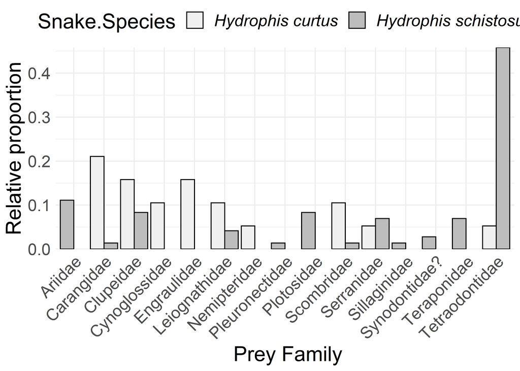

## 4.6 Diverisity of prey families found in gut content

[output not shown]

[output not shown]

| Snake.Species | Prey.Family.Richness |
| --- | --- |
| Hydrophis curtus | 10 |
| Hydrophis schistosus | 13 |

[output not shown]

[output not shown]

[output not shown]

## 4.7 Overlap in prey of *H. curtus* and *H. schsitosus*

| Overlap |
| --- |
| 7 |

[output not shown]

[output not shown]

[output not shown]

[output not shown]

## 4.8 Prey preference

| Snake.Species | Prey.Family | per.F | per.W | per.N | IRI | rank |
| --- | --- | --- | --- | --- | --- | --- |
| Hydrophis schistosus | Tetraodontidae | 34.246575 | 38.7307267 | 35.869565 | 2554.804519 | 1 |
| Hydrophis curtus | Unidentified | 44.827586 | 15.2823920 | 40.625000 | 2506.193436 | 1 |
| Hydrophis schistosus | Unidentified | 23.287671 | 12.9453244 | 21.739130 | 807.720182 | 2 |
| Hydrophis curtus | Clupeidae | 6.896552 | 29.9003322 | 9.375000 | 270.864360 | 2 |
| Hydrophis curtus | Engraulidae | 10.344828 | 11.9601329 | 9.375000 | 220.708271 | 3 |
| Hydrophis curtus | Carangidae | 13.793103 | 3.3222591 | 12.500000 | 218.238057 | 4 |
| Hydrophis schistosus | Ariidae | 9.589041 | 8.8407094 | 8.695652 | 168.156891 | 3 |
| Hydrophis schistosus | Clupeidae | 6.849315 | 10.9456402 | 6.521739 | 119.639584 | 4 |
| Hydrophis schistosus | Plotosidae | 8.219178 | 7.7882440 | 6.521739 | 117.616299 | 5 |
| Hydrophis curtus | Scombridae | 6.896552 | 6.6445183 | 6.250000 | 88.927712 | 5 |
| Hydrophis schistosus | Teraponidae | 6.849315 | 6.5673841 | 5.434783 | 82.206621 | 6 |
| Hydrophis schistosus | Serranidae | 5.479452 | 7.6303742 | 5.434783 | 71.589900 | 7 |
| Hydrophis curtus | Cynoglossidae | 6.896552 | 3.9867110 | 6.250000 | 70.598007 | 6 |
| Hydrophis curtus | Serranidae | 3.448276 | 16.6112957 | 3.125000 | 68.056192 | 7 |
| Hydrophis curtus | Leiognathidae | 6.896552 | 2.9900332 | 6.250000 | 63.724367 | 8 |
| Hydrophis curtus | Tetraodontidae | 3.448276 | 7.6411960 | 3.125000 | 37.124814 | 9 |
| Hydrophis schistosus | Leiognathidae | 4.109589 | 1.0524654 | 3.260870 | 17.726034 | 8 |
| Hydrophis curtus | Nemipteridae | 3.448276 | 1.6611296 | 3.125000 | 16.503895 | 10 |
| Hydrophis schistosus | Synodontidae? | 2.739726 | 1.1840236 | 2.173913 | 9.199826 | 9 |
| Hydrophis schistosus | Sillaginidae | 1.369863 | 2.4206704 | 1.086957 | 4.804968 | 10 |
| Hydrophis schistosus | Scombridae | 1.369863 | 1.2103352 | 1.086957 | 3.146975 | 11 |
| Hydrophis schistosus | Pleuronectidae | 1.369863 | 0.3683629 | 1.086957 | 1.993588 | 12 |
| Hydrophis schistosus | Carangidae | 1.369863 | 0.3157396 | 1.086957 | 1.921502 | 13 |

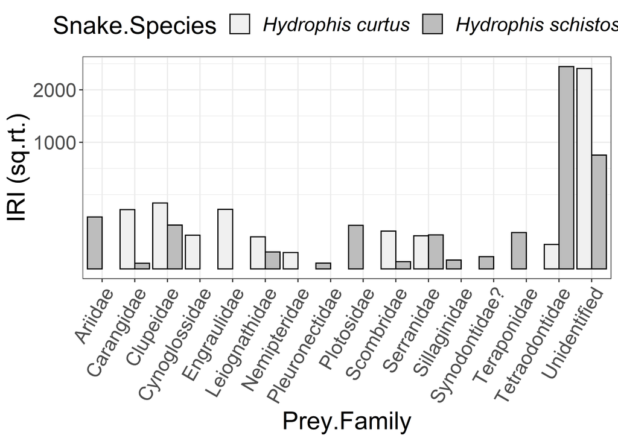

## 4.9 Selectivity of prey sizes

**Variable type: numeric**

| Snake.Species | n_missing | complete_rate | mean | sd | p0 | p25 | p50 | p75 | p100 |
| --- | --- | --- | --- | --- | --- | --- | --- | --- | --- |
| Hydrophis curtus | 1 | 0.86 | 2.59 | 0.57 | 2.00 | 2.18 | 2.45 | 2.88 | 3.5 |
| Hydrophis schistosus | 0 | 1.00 | 3.59 | 1.32 | 1.06 | 3.35 | 3.80 | 4.30 | 5.5 |

| estimate | estimate1 | estimate2 | statistic | p.value | d |
| --- | --- | --- | --- | --- | --- |
| -0.6961959 | 2.76775 | 3.463946 | -2.386272 | 0.0237889 | 0.6420566 |

# 5 Difference in resouce use betweek *H. curtus* and *H. schistosus*?

Carbon and Nitrogen isotope ratios were compared accorss species. Plasma and scale samples were used to compare short term and long term resource use respectively. Multiples metrics including niche width (SEA), variance (range), overlap (%) were used.

## 5.1 Number of samples analysed

| Species | Plasma | Scales |
| --- | --- | --- |
| Hydrophis curtus | 6 | 12 |
| Hydrophis schistosus | 27 | 25 |

## 5.2 Summary statistics on Carbon and Nitrogen stable isotopes

| Species | Tissue.type | Delta.Carbon | Delta.Nitrogen |
| --- | --- | --- | --- |
| Hydrophis curtus | Plasma | -17.6±0.6 | 13.23±0.56 |
| Hydrophis curtus | Scales | -15.44±0.59 | 14.57±1.26 |
| Hydrophis schistosus | Plasma | -16.72±1.14 | 14.45±1.12 |
| Hydrophis schistosus | Scales | -14.95±1.25 | 15.13±1.14 |

## 5.3 Difference in niche width between sea snakes

[output not shown]

[output not shown]

### 5.3.1 Maximum likelihood estimate of SEA

[output not shown]

[output not shown]

As maximum likelihood can only porivde point estimates of SEA, a bayesian model was used to provide more robust comparison of niche width.

### 5.3.2 Bayesian estimate of SEA

[output not shown]

[output not shown]

[output not shown]

[output not shown]

[output not shown]

[output not shown]

[output not shown]

### 5.3.3 Testing difference in species niche area by tissue type

[output not shown]

Hyp: *H. schistosus* SEA is larger than *H. curtus*

## 5.4 Visualising posterior ellipses to compare species isotopic niche

[output not shown]

[output not shown]

[output not shown]

[output not shown]

[output not shown]

[output not shown]

[output not shown]

[output not shown]

## 5.5 Relative overlap in bayesian standard ellipses

[output not shown]

[output not shown]

[output not shown]

[output not shown]

[output not shown]

[output not shown]

[output not shown]

- low sample size for *H. curtus*
- differences in processing of scales and plasma, i.e., lipid extraction

# 6 Does fishing intensity affect the distribution of *H. curtus* and *H. schistosus*?

## 6.1 Spatial overlap between fisheries and sea snakes

| gear | sp | overlap | extent.sp | rel.ovlp |
| --- | --- | --- | --- | --- |
| GillNet | HC | 30 | 49 | 0.6122449 |
| GillNet | HS | 39 | 51 | 0.7647059 |
| Trawler | HC | 47 | 49 | 0.9591837 |
| Trawler | HS | 46 | 51 | 0.9019608 |

[output not shown]

## 6.2 Variation in relative proportion of HC with fishing intensity

| term | estimate | std.error | statistic | p.value |
| --- | --- | --- | --- | --- |
| (Intercept) | -0.2644395 | 0.1108086 | -2.3864521 | 0.0197591 |
| GillNet | 0.0030194 | 0.0062982 | 0.4794069 | 0.6331652 |
| Trawler | -0.0004375 | 0.0012801 | -0.3417601 | 0.7335702 |
| mean.depth | -0.0258173 | 0.0037580 | -6.8699998 | 0.0000000 |

| adj.r.squared | AIC |
| --- | --- |
| 0.3899049 | 65.93959 |

[output not shown]

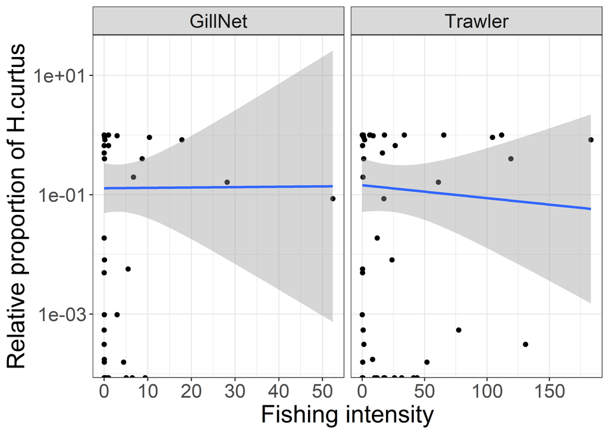

# 7 Overlap between fisheries catch and sea snake diet

[output not shown]

[output not shown]

## 7.1 Sampling Adequacy

| Gear.Type | N | Haul.Hours |
| --- | --- | --- |
| Gill Net | 38 | 35.41667 |
| Trawler | 140 | 434.65000 |

## 7.2 Catch weight

[output not shown]

[output not shown]

[output not shown]

## 7.3 Diverisity of prey families found in fisheries catch

| Gear.Type | Family.Richness |
| --- | --- |
| Gill Net | 15 |
| Trawler | 48 |

## 7.4 No. of Sea snake prey families found in fish catch and overlap

| Gear.Type | snake | Nfam |
| --- | --- | --- |
| Gill Net | HC | 7 |
| Gill Net | HS | 6 |
| Trawler | HC | 9 |
| Trawler | HS | 9 |

| Gear.Type | snake | Mean.prop |
| --- | --- | --- |
| Gill Net | HC | 0.8204191 |
| Gill Net | HS | 0.7958067 |
| Trawler | HC | 0.7356892 |
| Trawler | HS | 0.4831901 |

| Gear.Type | estimate | HC | HS | statistic | p.value | d |
| --- | --- | --- | --- | --- | --- | --- |
| Gill Net | 0.0246124 | 0.8204191 | 0.7958067 | 0.6314888 | 0.5296802 | 0.1448735 |
| Trawler | 0.2524990 | 0.7356892 | 0.4831901 | 7.0551602 | 0.0000000 | 0.8924545 |

| snake | estimate | GN | TR | statistic | p.value | d |
| --- | --- | --- | --- | --- | --- | --- |
| HC | 0.0847299 | 0.8204191 | 0.7356892 | 2.469163 | 0.0153629 | 0.3588295 |
| HS | 0.3126166 | 0.7958067 | 0.4831901 | 7.761277 | 0.0000000 | 1.0913295 |

## 7.5 Sea snake prey species in fisheries catch

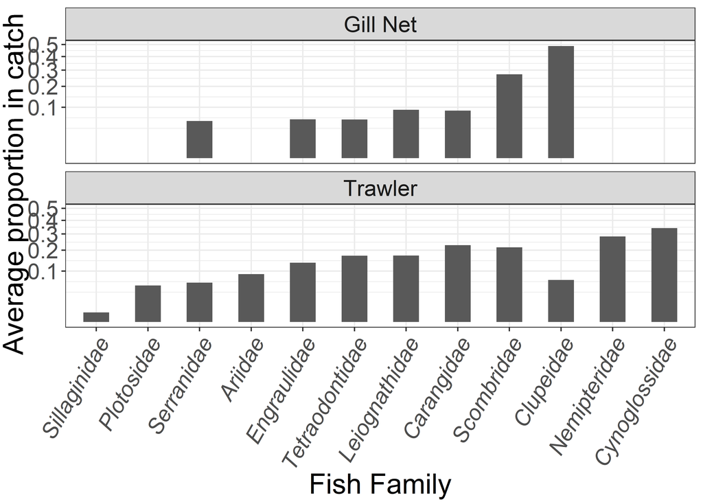

# 8 Does isotopic niche of sea snakes change with local fishing intensity?

As it is infeasible to to find sites with little to no fishing pressure on mainland India. The ultimate objective of this project remains unfulfilled it is nigh impossible to conduct a study with controls and test sites with varying levels of fishing pressure.

- How do you test the niche shift hypotheses with out spatial replicates?

  While the control - test study design failed, fishing effort data was collected from multiple vessels (Gillnet and Trawlers) landing at the Malvan harbour over the period of 1.5 years along side diet, abundance (snakes and prey), and isotopic data. So we ask the following questions:
  - Is there a corellation between fishing intensity and isotopic ratios?
  - Do niche metrics (width, overlap) vary with fishing pressure (high, medium and low preiods during the year)?

  What temporal resolution should be used for the analysis?
  - Day, week, month or season.
- Which is appropriate and why?

  Depending on the tissue being analysed. Scales - month, Plasma - week
- What are the existing data and sampling structures and what can be improved?

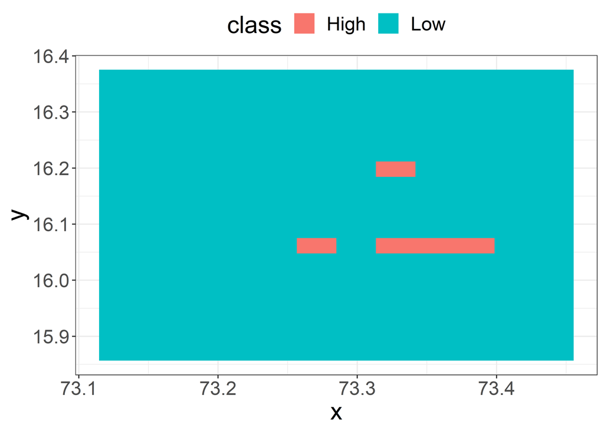

```r
#Stable isotope data

sia = read.csv("./Data/Stable Isotope Data_CEAS_241119.csv")

#joining sia data to snake data

sia_snakes = sia%>%
  filter(Tissue.type != "Gut Content")%>%
  left_join(snakes, 'Field.Code')%>%
  mutate(Lab = "CEAS")%>%
  rename(Delta.Carbon = d13C..vpdb. , Delta.Nitrogen = d15N..N2.air.)%>%
  dplyr::select(Date, Field.Code, Species, Snout.to.Vent..cm., Sex, Gravid, Class,
                Gear.Type, Fishing.Location, Depth.Caught..m.,
                Plasma.Color, Delta.Carbon, Delta.Nitrogen, Lab,
                Tissue.type, Month, Year)

#selecting relavant variables

sia_fi = sia_snakes%>%
  dplyr::select(Field.Code, Species, Fishing.Location, Depth.Caught..m.,Tissue.type,
                Delta.Carbon, Delta.Nitrogen)%>%
  filter(Fishing.Location != "")%>%
  drop_na()%>%
  droplevels()

# Geocoding capture location

sia_fi <- sia_fi%>%
  ungroup()%>%
  mutate(Fishing.Location = as.character(Fishing.Location))%>%
  mutate_geocode(location = Fishing.Location)

# Extracting coordinates from depth data

library(fuzzyjoin)

#matching funtions for theta join

depth_match <- function(x,y){
  x <- -x
  x <= y+0.5 & x >= y-0.5 #interval for theta matching depth
}

lat_match <- function(x,y){
  x <= y+0.005 & x >= y-0.005 #interval for theta matching latitude
}

sia_fi <- sia_fi%>%
  mutate(depth = Depth.Caught..m.)%>%
  fuzzy_inner_join(y = depth, by = c("depth", "lat"),
                   match_fun = list(depth = depth_match,
                                    lat = lat_match))%>%
  dplyr::select(Field.Code, Species, Fishing.Location, Depth.Caught..m., Tissue.type,
                Delta.Carbon, Delta.Nitrogen, lon.y, lat.x)%>%#dplyr::selecting relevant variables
  rename(lon = lon.y,# longitude from fishing location
         lat = lat.x)%>%# latitude from depth data
  distinct(Field.Code, Tissue.type, .keep_all = T)

# Finding grid cell in which snake was captured

cell.ext <- function(df){

  r <- raster::projectRaster(ext, crs = CRS("+proj=longlat +ellps=WGS84 +datum=WGS84 +no_defs"))

  xy <- df

  coordinates(xy) <- ~lon + lat

  proj4string(xy) <- CRS("+init=epsg:4326")#setting projection to WGS 84 (lon/lat)

  #xy <- spTransform(xy, CRSobj = CRS("+init=epsg:3857"))#using spherical mercator

  c <- xyFromCell(r, cellFromXY(r, xy))

}

sia_li <- sia_fi%>%
  group_by(Field.Code, Species, Tissue.type, Delta.Carbon, Delta.Nitrogen)%>%
  nest()%>%
  mutate(cell = map(data, cell.ext),
         celldf = map(cell, as.data.frame))%>%
  dplyr::select(celldf)%>%
  unnest()%>%
  inner_join(fi, by = c("x", "y"))

write.csv(sia_li, "./Data/SIA_fishing intensity.csv")
```

## 8.1 Sample size

```
##
##                        Plasma Scales
##   Hydrophis schistosus     11     12
```

## 8.2 Variation Carbon isotope ratio with fishing intensity

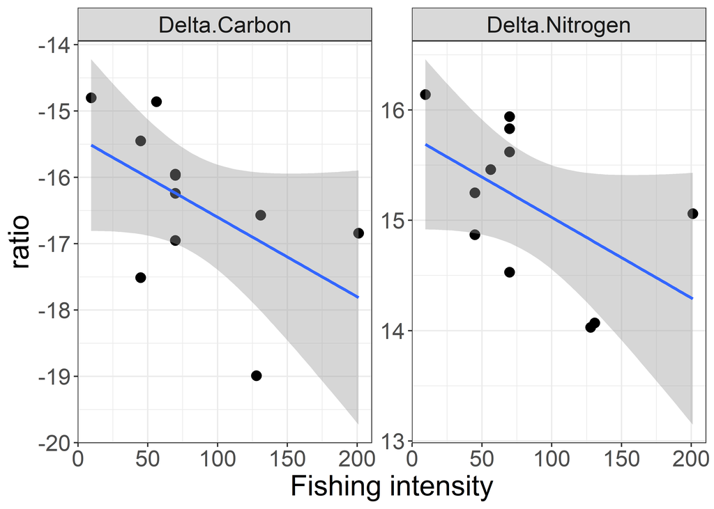

## 8.3 Modeling isotope ratios with fishing intensity

### 8.3.1 Continous model

[output not shown]

## 8.4 Difference in niche width between sea snakes

[output not shown]

[output not shown]

### 8.4.1 Maximum likelihood estimate of SEA

[output not shown]

[output not shown]

As maximum likelihood can only porivde point estimates of SEA, a bayesian model was used to provide more robust comparison of niche width.

### 8.4.2 Bayesian estimate of SEA

[output not shown]

[output not shown]

[output not shown]

[output not shown]

[output not shown]

[output not shown]

[output not shown]

### 8.4.3 Testing difference in species niche area by tissue type

[output not shown]

[output not shown]